# Using the tidycensus package

This notebook is one of several that demonstrate different ways to use census related R packages. In all examples, we’ll build a map of median household income for Texas counties.

This version of our Census tour includes [Kyle Walker](http://personal.tcu.edu/kylewalker/)’s [tidycensus](https://walkerke.github.io/tidycensus/index.html) package. It returns census data in tidyverse-ready data frames and includes an option to pull the associated spatial geometry.

This package requires that an Census API Key be installed. See documentation.

```r
library(tidyverse)
library(tidycensus)
```

## Find the variables

To figure out which variables we need we can use the `load_variables` function.

```r
v17 <- load_variables(2017, "acs5", cache = TRUE)
```

You can then view the `v17` data frame and filter to find the variables you need.

I our case we need `B19013_001` for “MEDIAN HOUSEHOLD INCOME IN THE PAST 12 MONTHS (IN 2017 INFLATION-ADJUSTED DOLLARS)”.

We will also get `B01003_001` for “TOTAL POPULATION” so we can show the difference in API returns of tidyverse vs censusapi.

## Get the data

In Kyle’s package he has separate functions to call for different data sets. We’ll use `get_acs()` to get our American Community Survey data.

```r
tx_income <- get_acs(
  geography = "county",
  variables = c("B01003_001","B19013_001"),
  state = "TX"
  )
tx_income %>% head()
```

| GEOID | NAME | variable | estimate | moe |
| --- | --- | --- | --- | --- |
| 48001 | Anderson County, Texas | B01003_001 | 57747 | NA |
| 48001 | Anderson County, Texas | B19013_001 | 42313 | 2337 |
| 48003 | Andrews County, Texas | B01003_001 | 17577 | NA |
| 48003 | Andrews County, Texas | B19013_001 | 70753 | 6115 |
| 48005 | Angelina County, Texas | B01003_001 | 87700 | NA |
| 48005 | Angelina County, Texas | B19013_001 | 46472 | 1452 |

Note that even though we are pulling two variables, there is only one estimate and moe column. Each new variable is added as a new row instead of as a new column. As you add more variables, the data gets longer, but not wider. This fits the “tidy” way of managing data.

## Add geometry to the download

To include the spatial geometry for a call is as easy as adding `geometry = TRUE`. In this case below, I dropped the population variable because I don’t need it for the map and would just have to filter it out.

```r
# catches shapefiles for future session to avoid redownloading.
options(tigris_use_cache = TRUE)

tx_income_map <- get_acs(
  geography = "county",
  variables = c("B19013_001"),
  state = "TX",
  geometry = TRUE
  )
```

## Make the map

Here we use the `geom_sf()` in ggplot to make a map.

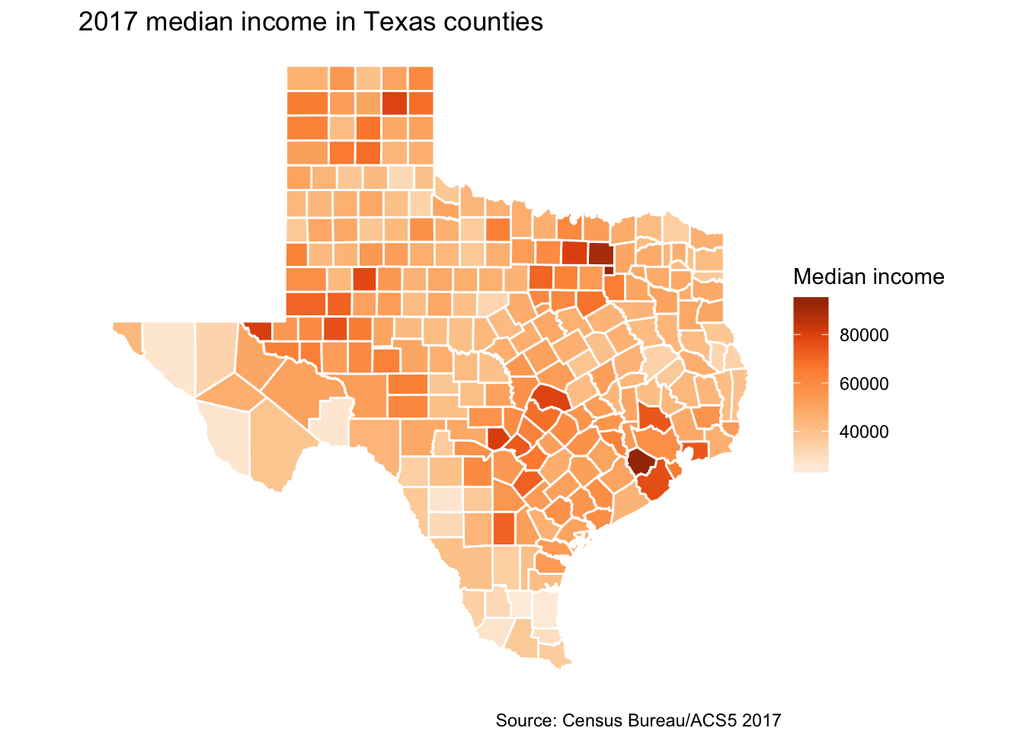

```r
ggplot(tx_income_map) +
  geom_sf(aes(fill=estimate), color="white") +
  theme_void() +
  theme(panel.grid.major = element_line(colour = 'transparent')) +
  scale_fill_distiller(palette="Oranges", direction=1, name="Median income") +
  labs(title="2017 median income in Texas counties", caption="Source: Census Bureau/ACS5 2017")
```

- The two theme calls adjust axis and grid lines.
- The scale option changes the color palatte and reverses the direction of the scale and updates the name on the legend.